# MEDS5420 - The Shell Part 1

January 21, 2026

# 1 Readings

Practical Computing for Biologists: Chapters 1, 4, 5, Appendix 3.

Unix Basics from UConn CBC: http://bioinformatics.uconn.edu/unix-basics/

Software Carpentry Shell Novice lesson: Episodes 1-4: https://swcarpentry.github.io/shell-novice/

# 2 Lesson overview

| Command | Function |
| --- | --- |
| `pwd` | **P**rint **W**orking **D**irectory |
| `cd` | **C**hange **D**irectoy (`cd`, `cd -`, `cd ~/<directory>`, `cd ..`) |
| `ls` | **L**i**s**t files (`ls -F`, `ls --help`) |
| `man` | **Man**ual page for a command |
| `mkdir` | **M**a**k**e a new **dir**ectory |
| `nano` | A rudimentary command-line text editor |
| `rm` | Delete file(s); use `rm -r <directory>` to delete directory and contents |
| `touch` | Create empty file |
| `cp` | **C**o**p**y files and directories |
| `mv` | **M**o**v**e or rename files and directories |
| `wc` | **W**ord **C**ount (`wc -l`) |
| `cat` | Print an entire file, or con**cat**enate multiple files |
| `less` | Read a file, one page at a time |
| `sort` | Sort lines (`sort -n`, `sort -r`) |
| `head` | Read beginning lines of a file (`head -n #`) |
| `tail` | Read last few lines of a file (`tail -n #`) |

## 2.1 Concepts:

- Terminology and basic commands
- Directory structure
- Navigating through command line: relative vs absolute paths
- Examining file contents
- Using the `*` wildcard to select multiple files in a directory, using the `[]` wildcard to select one or more letters, e.g. `*[AB].txt` for file names ending in A or B.
- Standard Output (stdout) and Standard Input (stdin) from commands can be combined using with pipes (`|`).
- Redirect stdout to files (`>`).

## 2.2 Why learn the command-line?

- The majority of bioinformatics and computational software is developed for command-line use from the shell
- Low system resource use (processor and memory)
- Easier to automate and more adaptable than GUIs
- Web-based tools are at risk of becoming obsolete (e.g. Galaxy, GenomeSpace) as more scientists devolop command-line competence

**Notes about reading these documents:**

Sections highlighted in grey are shell input or “standard input” (`stdin`).  
Lines following it prefixed by `'##'` denote shell output or “standard output” (`stdout`):

```bash
x='Welcome to MEDS 5420'
echo $x
```

```
## Welcome to MEDS 5420
```

# 3 Interacting with your computer: the terminal

You will communicate with the operating system (OS) by typing commands into the **terminal window**. You can use the terminal window to:

- navigate anywhere on your computer (including access to hidden files)
- get information (e.g. list contents of a directory)
- perform simple tasks (e.g. move files)
- perform moderately complex tasks: (e.g. parse a file or invoke a pipeline)
- launch applications (e.g. web browsers, bioinformatics utilities)
- stop or ‘kill’ applications

# 4 Bash, Shell, Terminal, Command Line: What’s the difference?

**Command Line** is the most general and refers to typing commands directly into a terminal that can be executed by the computer.  
**Shell** (sh) is specific program (language written by Steve Bourne while at Bell Labs) that processes commands and returns output.  
**Bash** stands for **B**ourne **A**gain **Sh**ell and is an updated version of the Shell language. This is the most popular Shell.  
**Terminal** is a user interface that takes input and provides an output in text format; the interface runs the input through Shell or Bash to process the command.

# 5 Navigating and inspecting directories from the terminal

## 5.1 Opening terminal

- On a Mac, use **Command-Space**, type “Terminal” and hit enter to open a terminal window.  
  The default interactive shell on Macs is now `zsh`, but to stay consistent between other platforms, please change this to `bash`.

First open the preferences tab:

[figure not shown]

Figure 1: Preferences Tab

Then change the shell to `/bin/bash`:

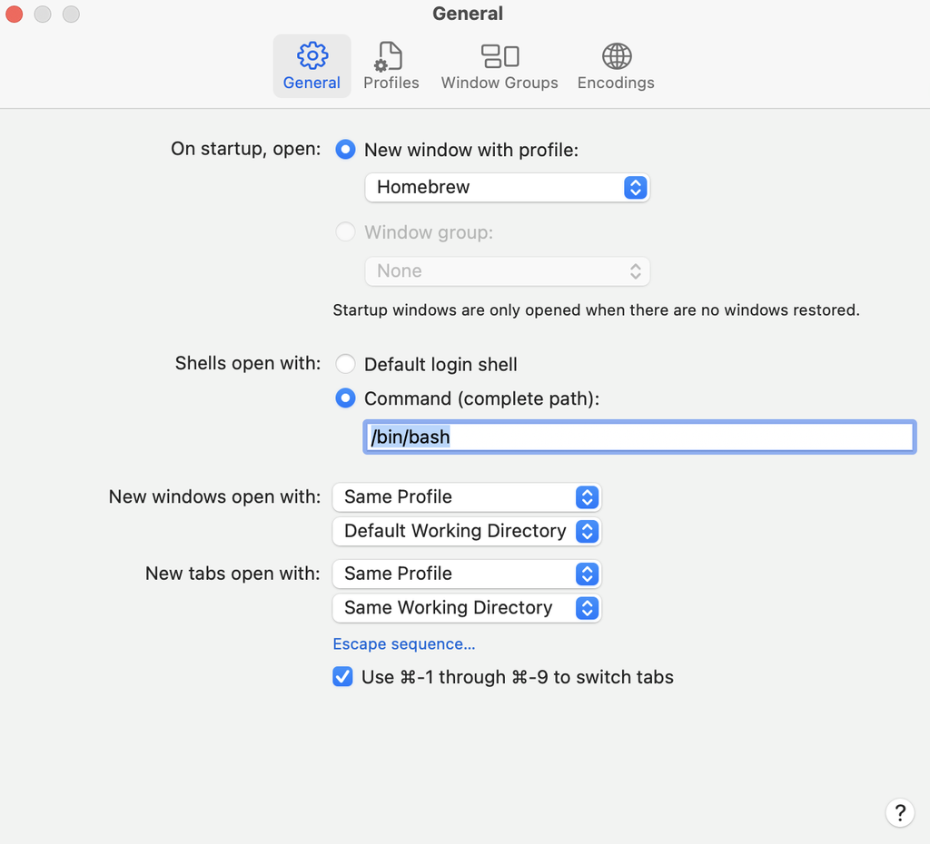

Figure 2: Change shell opens with to `/bin/bash`

- On Ubuntu Linux, use the search tab (top left icon in launch pad) to search for “Terminal”. Open it and lock it to the launch pad by right clicking.
- For Windows users see this link: https://www.laptopmag.com/articles/use-bash-shell-windows-10

## 5.2 Directory structure

Directories (or folders) are arranged based on how inclusive they are. Higher level directories are more inclusive and lower level directories are less inclusive or more specific.

The highest directory is known as the root directory (`/`). The home directory is typically the directory of the user you logged in as, and is where your terminal sessions will open up.

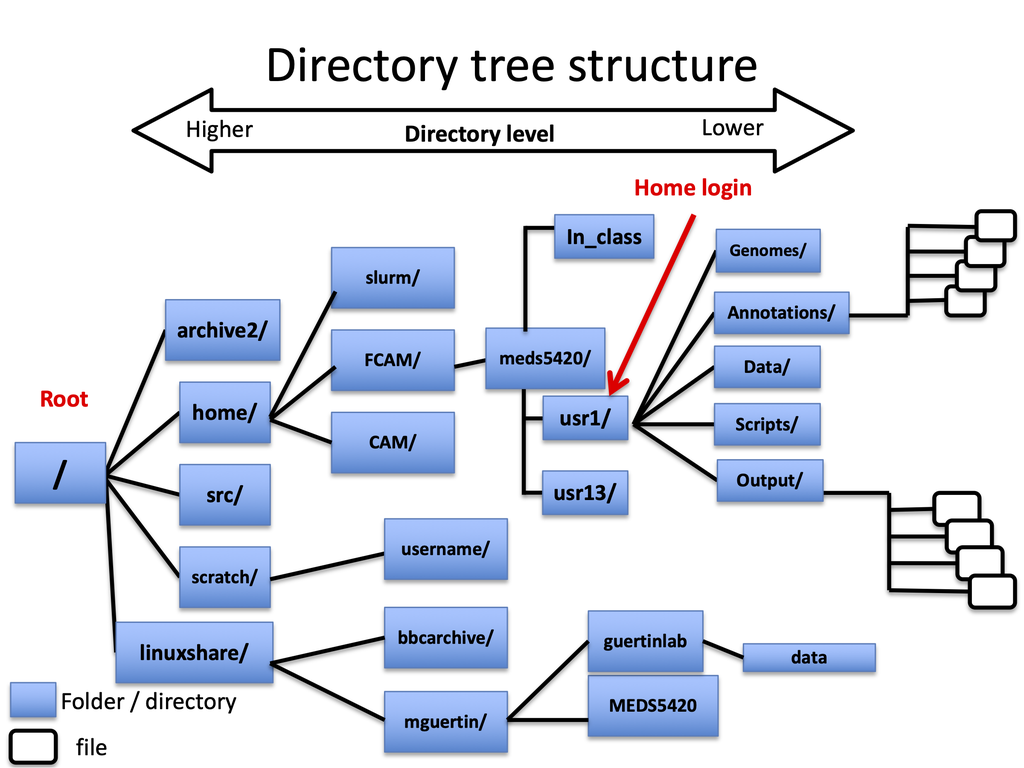

Figure 3: Directory Structure

To find out where you are in the directory listings type the following:

```bash
pwd
```

**`pwd`** stands for **p**rint **w**orking **d**irectory. The answer you get from the shell is the **path** of your current location, which in this case is your home directory.

To list the contents of the directory you can use **`ls`** (**l**i**s**t):

```bash
ls
```

To differentiate between directories and files, use the `-F` argument:

```bash
ls -F
```

**`ls`** like many shell programs can take on many arguments to change its behavior. To learn about the arguments of **`ls`**, read the **`man`** (manual) pages:

```bash
man ls
```